# trial0

Time in central zone:

NA

Crosses to the right:

0

Crosses to the left:

0

Number of freezes:

34

Total freeze time:

281.65

Freeze time ratio:

0.31

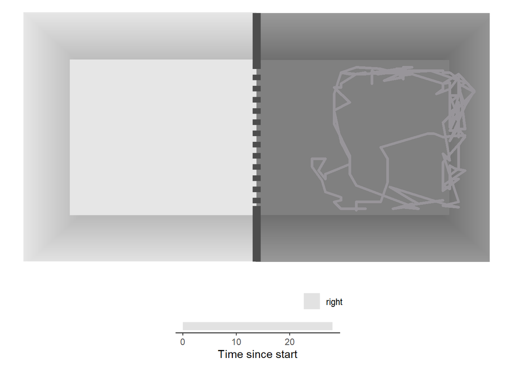

Animal:

animal_5

Distance:

3270.88

Time in left zone:

NA

Time in right zone:

26.43

Time in central zone:

NA

Crosses to the right:

0

Crosses to the left:

0

Number of freezes:

0

Total freeze time:

0

Freeze time ratio:

0

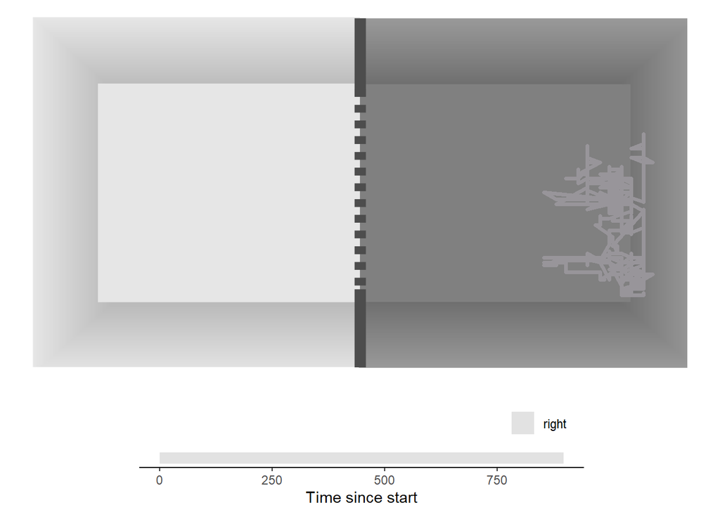

Animal:

animal_5

Distance:

8234

Time in left zone:

NA

Time in right zone:

898.13

Time in central zone:

NA

Crosses to the right:

0

Crosses to the left:

0

Number of freezes:

24

Total freeze time:

328.79

Freeze time ratio:

0.37

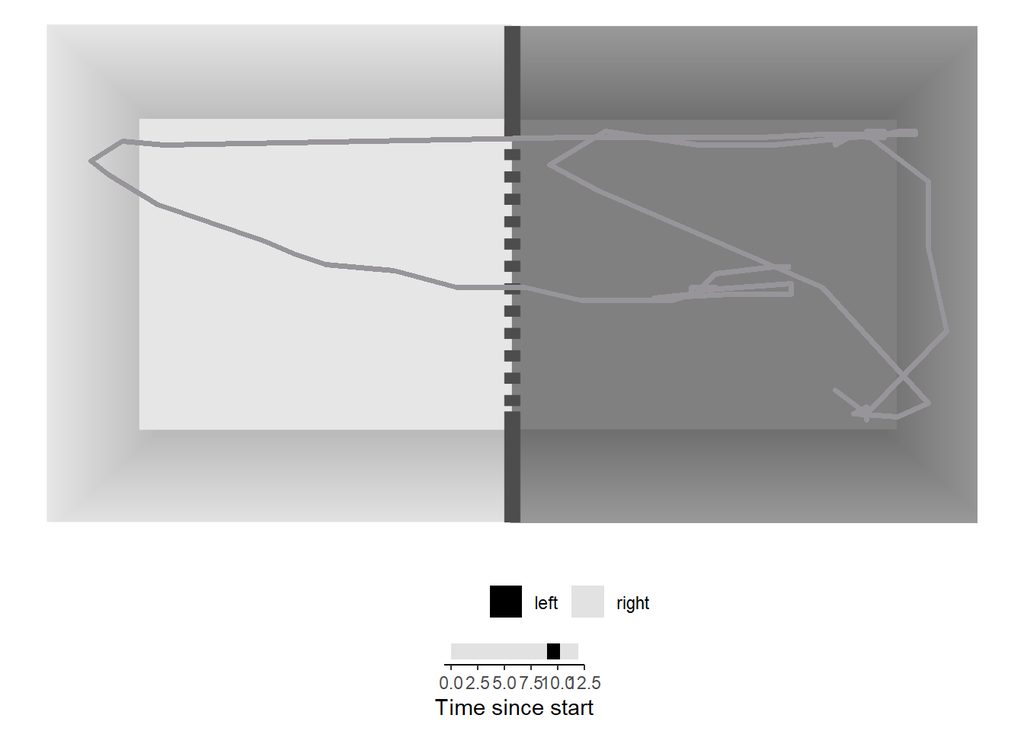

Animal:

animal_6

Distance:

1801.22

Time in left zone:

1.12

Time in right zone:

10.59

Time in central zone:

0.22

Crosses to the right:

1

Crosses to the left:

1

Number of freezes:

0

Total freeze time:

0

Freeze time ratio:

0

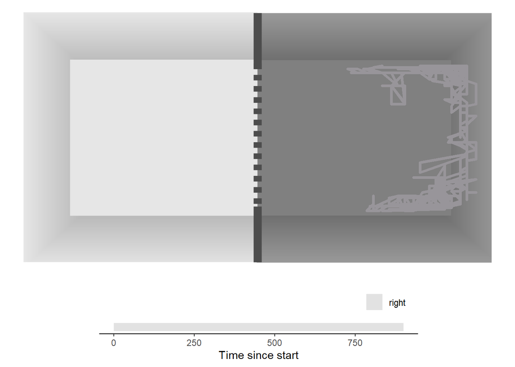

Animal:

animal_6

Distance:

14426.54

Time in left zone:

NA

Time in right zone:

899.98

Time in central zone:

NA

Crosses to the right:

0

Crosses to the left:

0

Number of freezes:

27

Total freeze time:

218.61

Freeze time ratio:

0.24

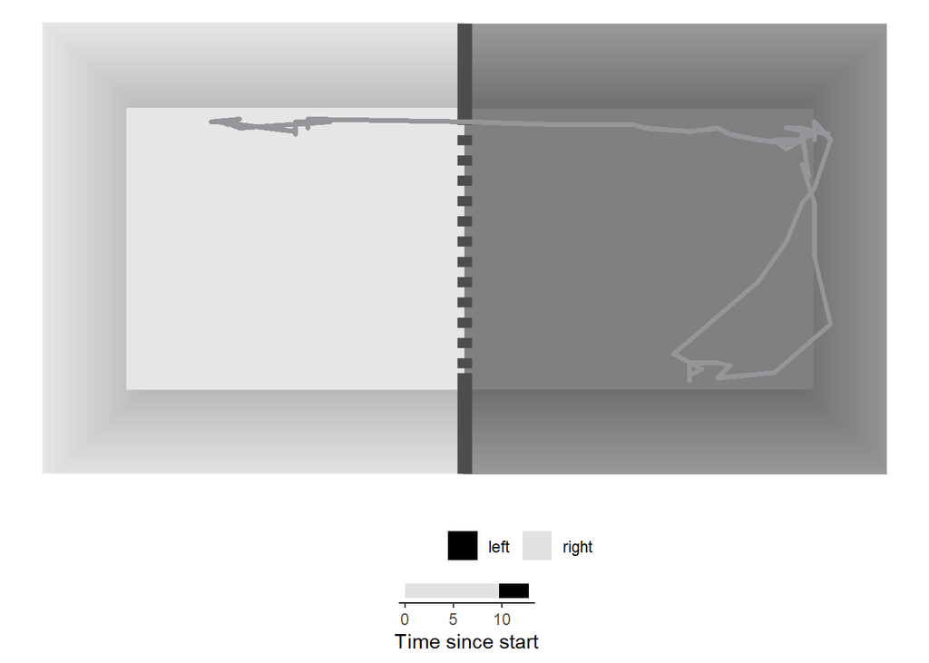

Animal:

animal_6

Distance:

1150.21

Time in left zone:

3.02

Time in right zone:

9.65

Time in central zone:

0.11

Crosses to the right:

0

Crosses to the left:

1

Number of freezes:

0

Total freeze time:

0

Freeze time ratio:

0

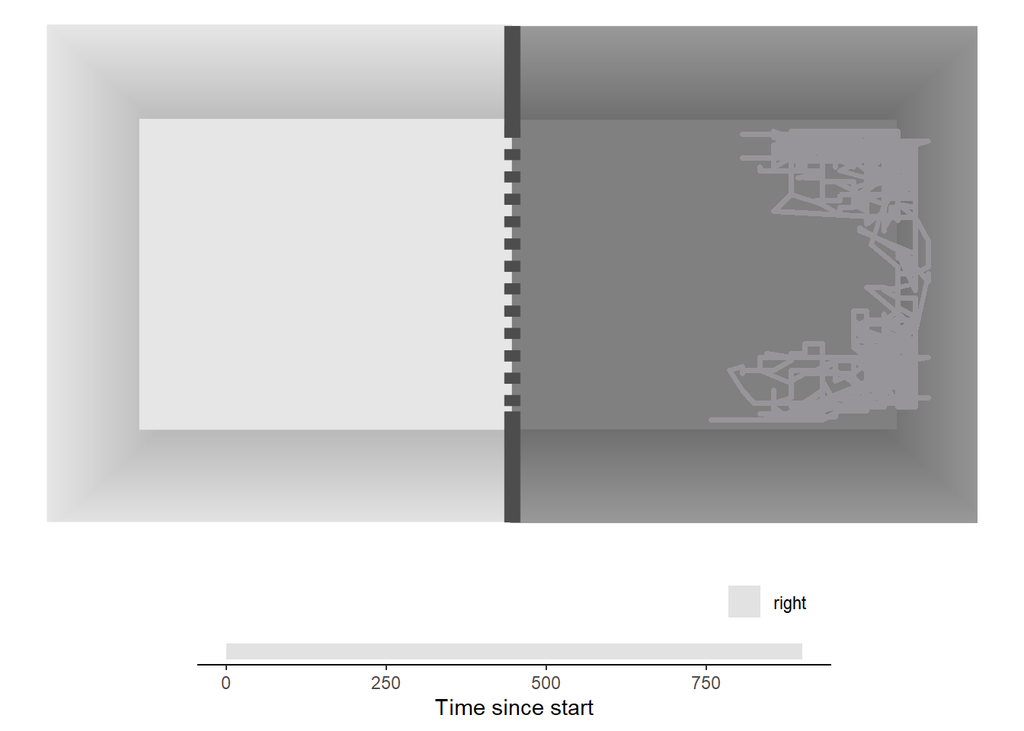

Animal:

animal_6

Distance:

22427.63

Time in left zone:

NA

Time in right zone:

899.93

Time in central zone:

NA

Crosses to the right:

0

Crosses to the left:

0

Number of freezes:

18

Total freeze time:

244.94

Freeze time ratio:

0.27

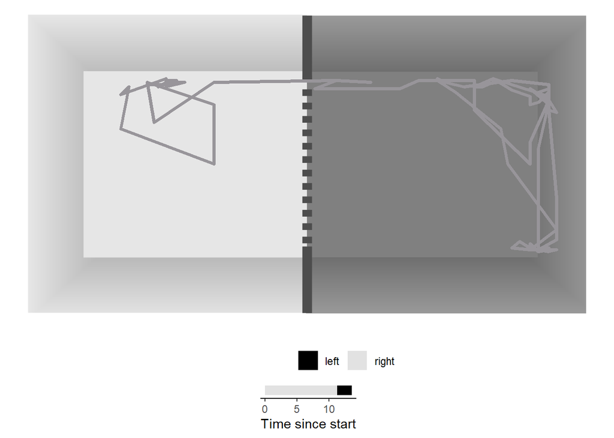

Animal:

animal_7

Distance:

2287.5

Time in left zone:

2.35

Time in right zone:

11.16

Time in central zone:

0.11

Crosses to the right:

0

Crosses to the left:

1

Number of freezes:

0

Total freeze time:

0

Freeze time ratio:

0

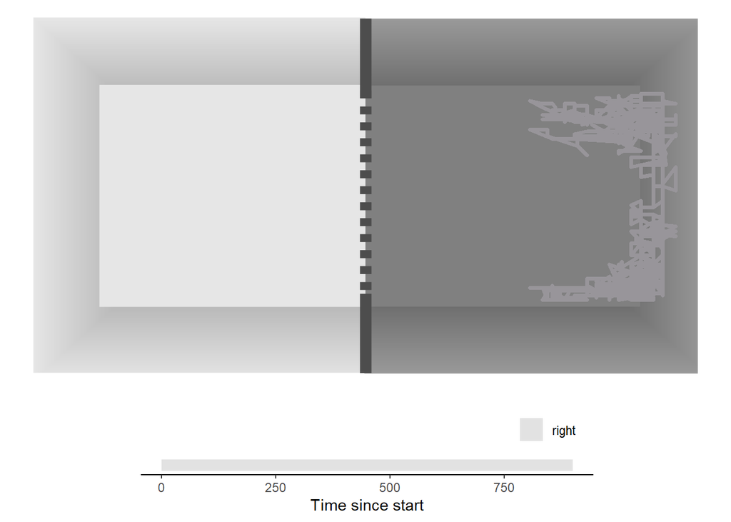

Animal:

animal_7

Distance:

18585.66

Time in left zone:

NA

Time in right zone:

899.92

Time in central zone:

NA

Crosses to the right:

0

Crosses to the left:

0

Number of freezes:

19

Total freeze time:

198.79

Freeze time ratio:

0.22

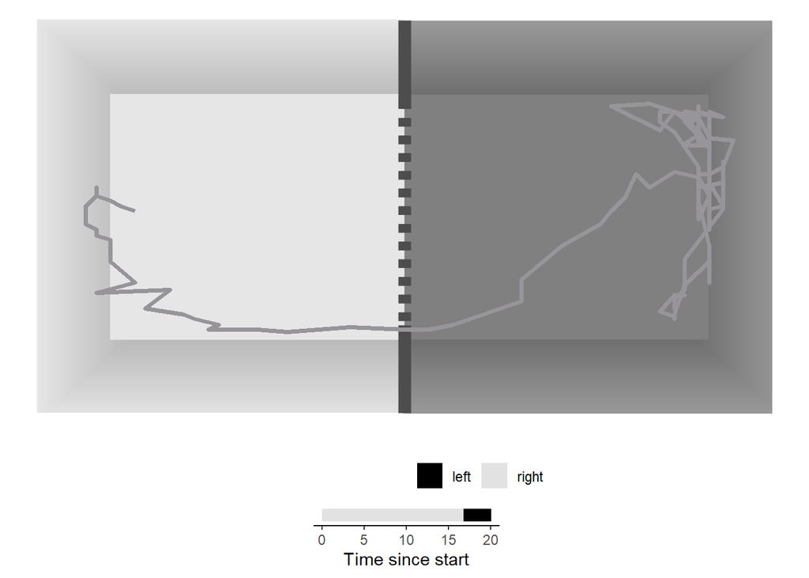

Animal:

animal_7

Distance:

2151.56

Time in left zone:

3.25

Time in right zone:

16.6

Time in central zone:

0.22

Crosses to the right:

0

Crosses to the left:

1

Number of freezes:

0

Total freeze time:

0

Freeze time ratio:

0

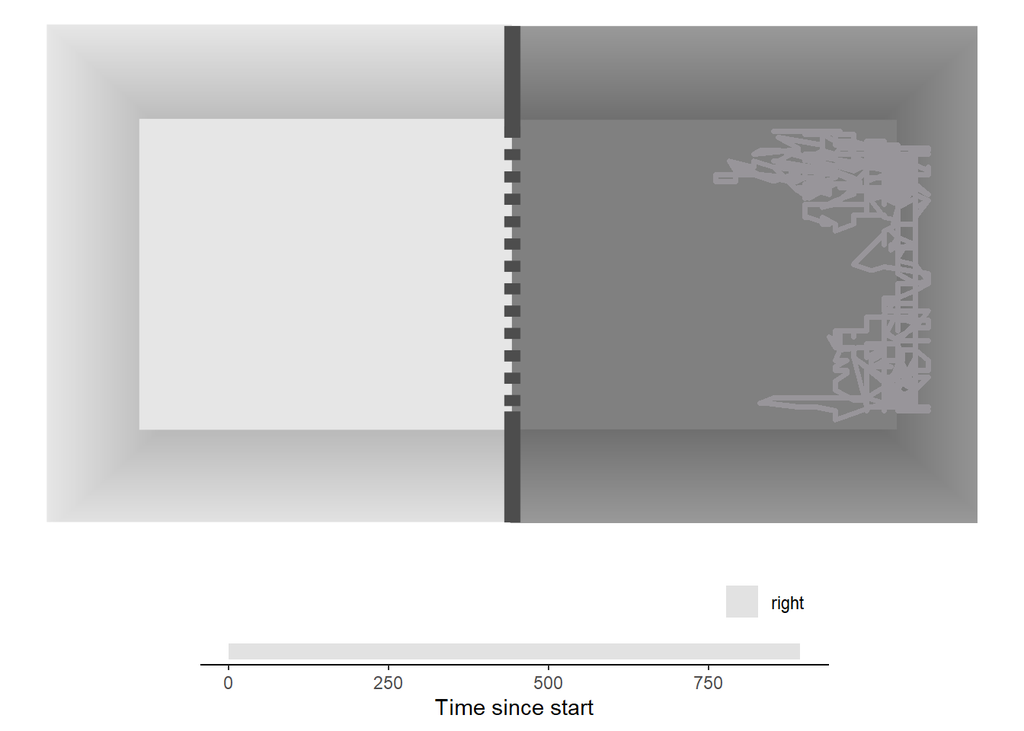

Animal:

animal_7

Distance:

15270.32

Time in left zone:

NA

Time in right zone:

892.88

Time in central zone:

NA

Crosses to the right:

0

Crosses to the left:

0

Number of freezes:

22

Total freeze time:

237.63

Freeze time ratio:

0.27

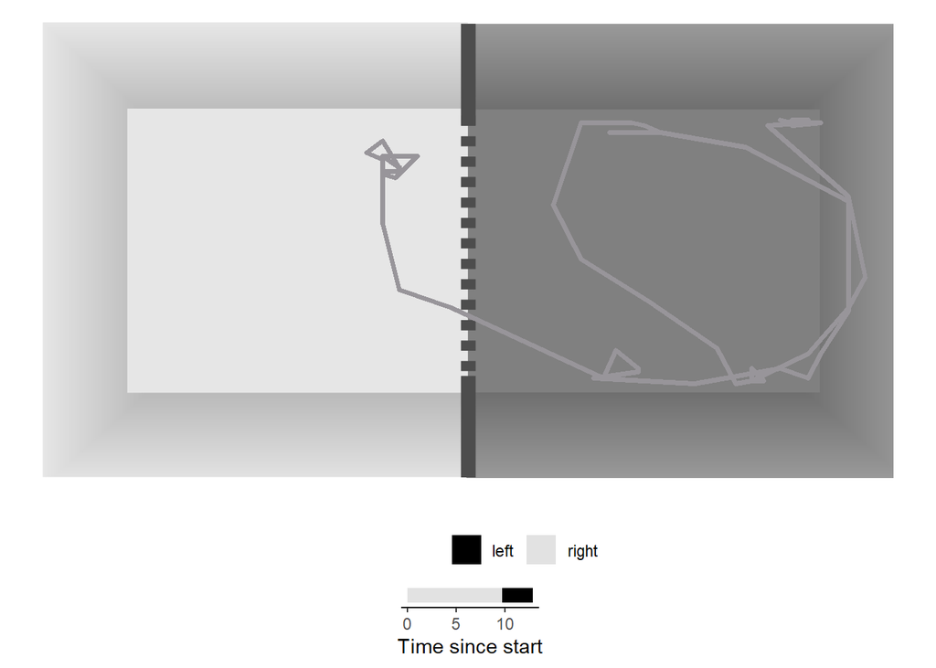

Animal:

animal_8

Distance:

1633.08

Time in left zone:

3.14

Time in right zone:

9.58

Time in central zone:

0.11

Crosses to the right:

0

Crosses to the left:

1

Number of freezes:

0

Total freeze time:

0

Freeze time ratio:

0

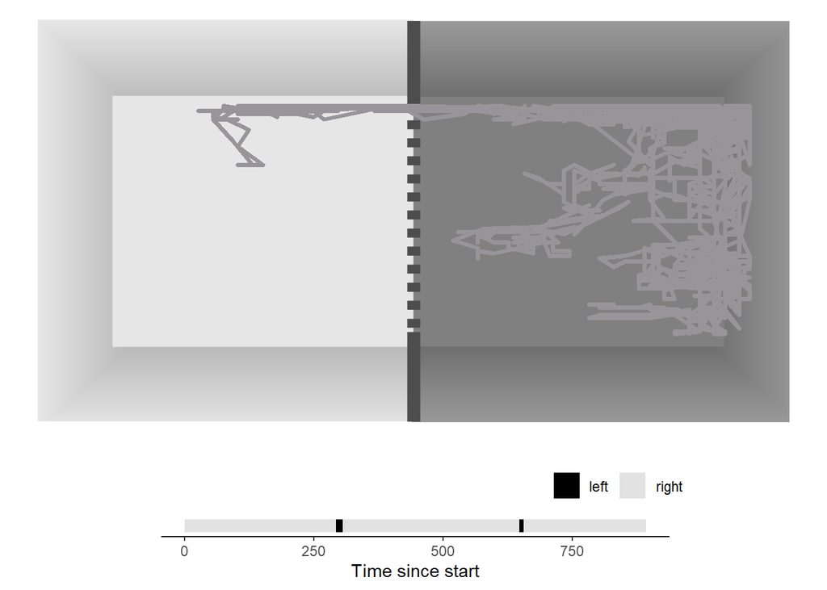

Animal:

animal_8

Distance:

26967.2

Time in left zone:

19.94

Time in right zone:

872.04

Time in central zone:

1.33

Crosses to the right:

2

Crosses to the left:

2

Number of freezes:

24

Total freeze time:

172.34

Freeze time ratio:

0.19

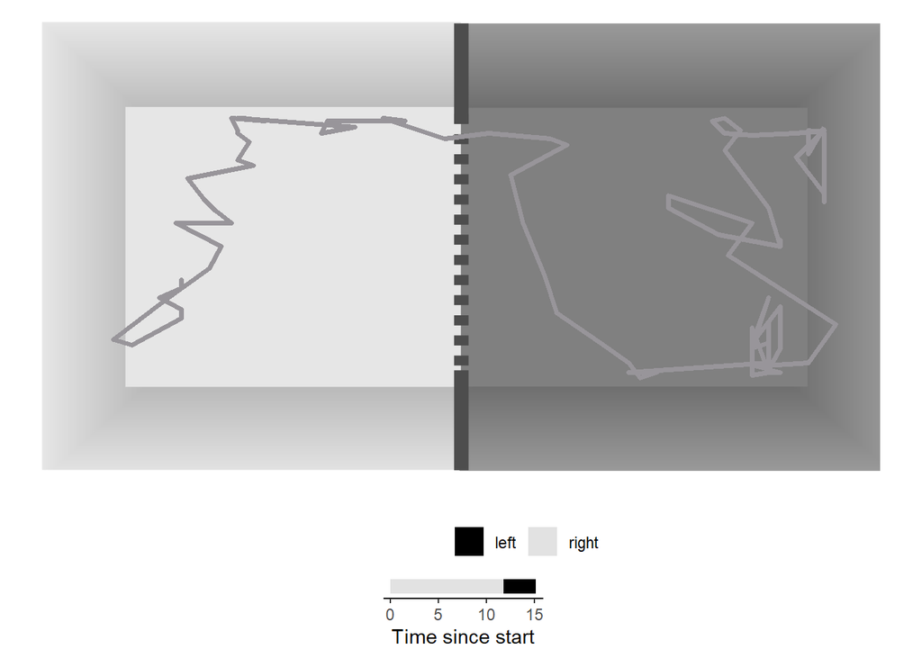

Animal:

animal_8

Distance:

2098.73

Time in left zone:

3.36

Time in right zone:

11.56

Time in central zone:

0.23

Crosses to the right:

0

Crosses to the left:

1

Number of freezes:

0

Total freeze time:

0

Freeze time ratio:

0

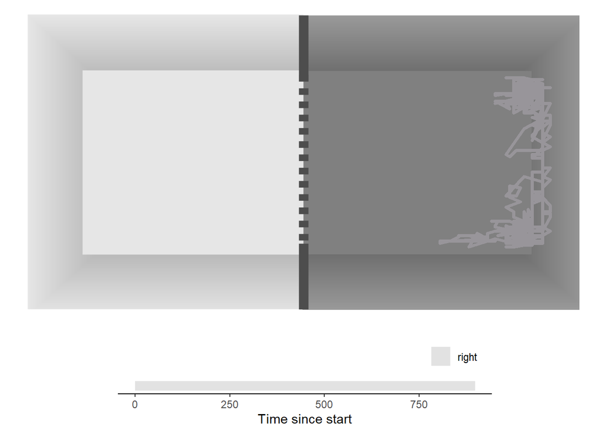

Animal:

animal_8

Distance:

15614.6

Time in left zone:

NA

Time in right zone:

896.83

Time in central zone:

NA

Crosses to the right:

0

Crosses to the left:

0

Number of freezes:

15

Total freeze time:

222.68

Freeze time ratio:

0.25

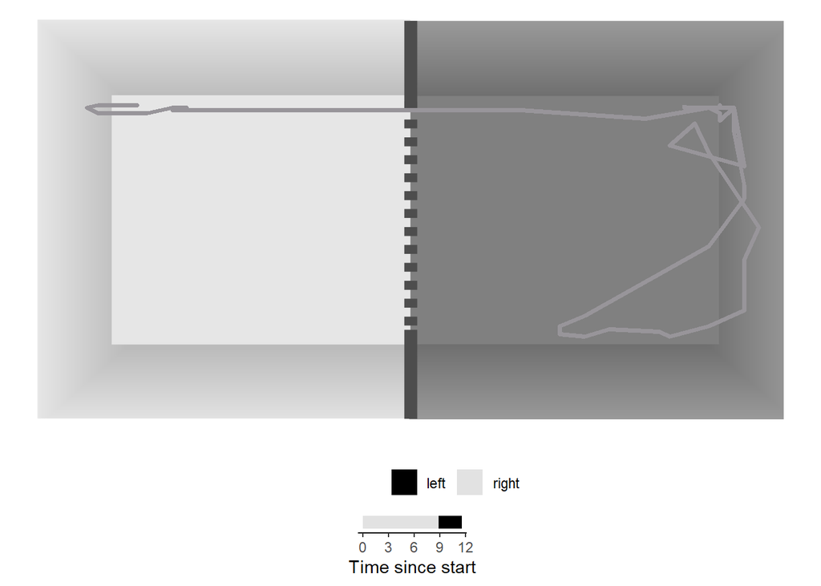

Animal:

animal_9

Distance:

1263.99

Time in left zone:

2.69

Time in right zone:

8.74

Time in central zone:

0.11

Crosses to the right:

0

Crosses to the left:

1

Number of freezes:

0

Total freeze time:

0

Freeze time ratio:

0

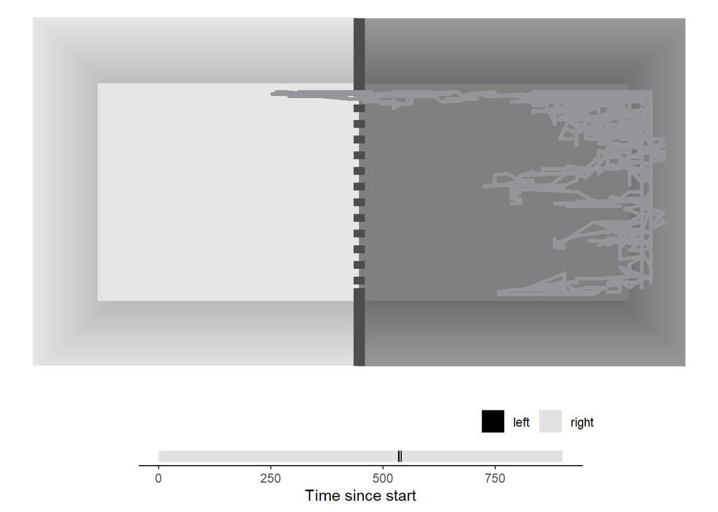

Animal:

animal_9

Distance:

20710.35

Time in left zone:

3.69

Time in right zone:

891.63

Time in central zone:

4.25

Crosses to the right:

2

Crosses to the left:

2

Number of freezes:

27

Total freeze time:

133.76

Freeze time ratio:

0.15

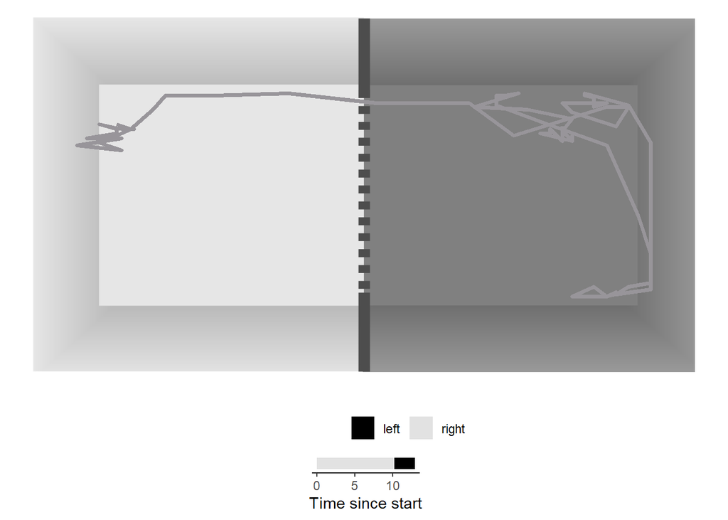

Animal:

animal_9

Distance:

1555.74

Time in left zone:

2.69

Time in right zone:

10.11

Time in central zone:

0.11

Crosses to the right:

0

Crosses to the left:

1

Number of freezes:

0

Total freeze time:

0

Freeze time ratio:

0

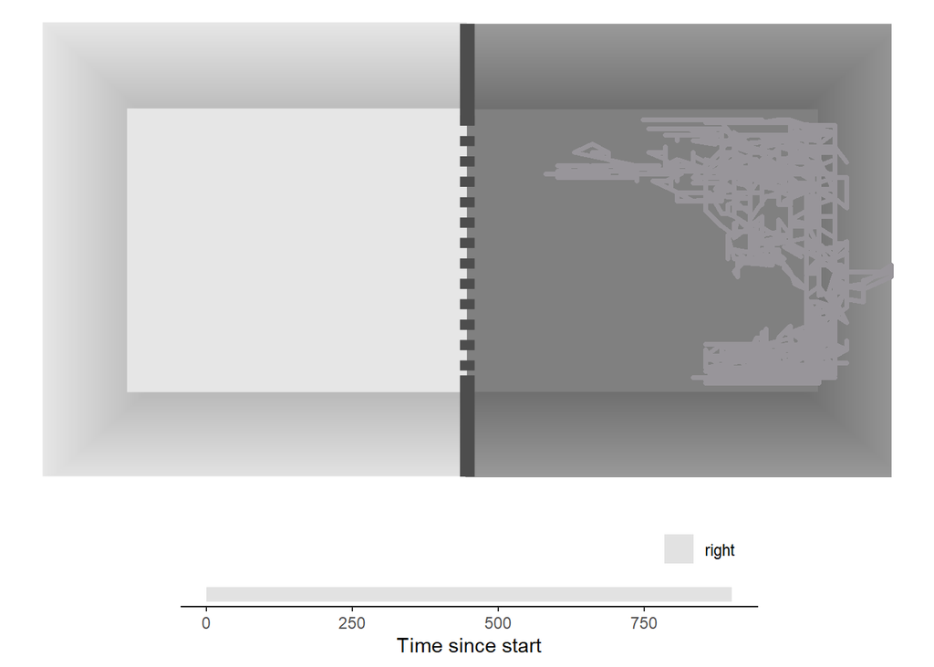

Animal:

animal_9

Distance:

22553.75

Time in left zone:

NA

Time in right zone:

899.46

Time in central zone:

NA

Crosses to the right:

0

Crosses to the left:

0

Number of freezes:

13

Total freeze time:

88.63

Freeze time ratio:

0.1

## Summary statistics

Animal:

Distance:

1674.57

Time in left zone:

2.17

Time in right zone:

10.26

Time in central zone:

0.21

Crosses to the right:

0.3

Crosses to the left:

1.1

Number of freezes:

0

Total freeze time:

0

Freeze time ratio:

0

Animal:

Distance:

19277.24

Time in left zone:

24.31

Time in right zone:

881.86

Time in central zone:

1.86

Crosses to the right:

0.8

Crosses to the left:

0.8

Number of freezes:

23.1

Total freeze time:

208.48

Freeze time ratio:

0.23

Animal:

Distance:

2043.6

Time in left zone:

2.78

Time in right zone:

13.94

Time in central zone:

0.38

Crosses to the right:

0

Crosses to the left:

0.9

Number of freezes:

0

Total freeze time:

0

Freeze time ratio:

0

Animal:

Distance:

18921.28

Time in left zone:

44.84

Time in right zone:

891.17

Time in central zone:

13.83

Crosses to the right:

0.4

Crosses to the left:

0.4

Number of freezes:

15.8

Total freeze time:

178.62

Freeze time ratio:

0.2